# Solar Panel Business Case

2026-07-07

## 1 Pre-Installation Forecast

Goal: Determine which, if any, of the solar quotes have a positive net present value based on historical usage data.

### 1.1 Usage Data (Apr 2019 to July 2022)

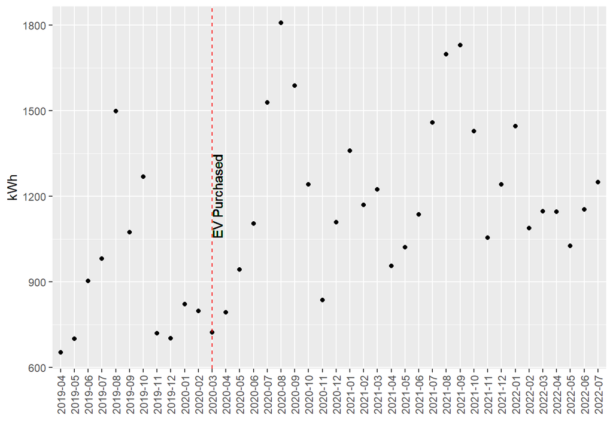

- Usage per year (KWh): 15,286
- Transmission Cost per year: $463.71
- Distribution Cost per year: $631.15
- Customer Cost per year: $120
- Generation Cost per year: $1,205.15
- Bill Total: $2,420.02

### 1.2 Options for Solar Systems

- Blue Raven:
  - Panels: 32
  - W per panel: 400
  - Total Generation (KW): 12.8 = 32*400
  - Yearly (KWh): 13,380
  - Total Cost: $46,341
  - Tax Break: $12,049
  - Net Cost: $34,292
  - 25 yr Efficiency: 92%
- EcoHouse
  - Panels: 39
  - W per panel: 360
  - Total Generation (KW): 14.04 = 39*360
  - Yearly (KWh): 15,453
  - Total Cost: $42,500
  - Tax Break: $12,750
  - Net Cost: $29,750
  - 25 yr Efficiency: 80%

### 1.3 Assumptions:

- Energy Inflation: 4%
- Overall Inflation: 2%

### 1.4 Forecast Timeseries

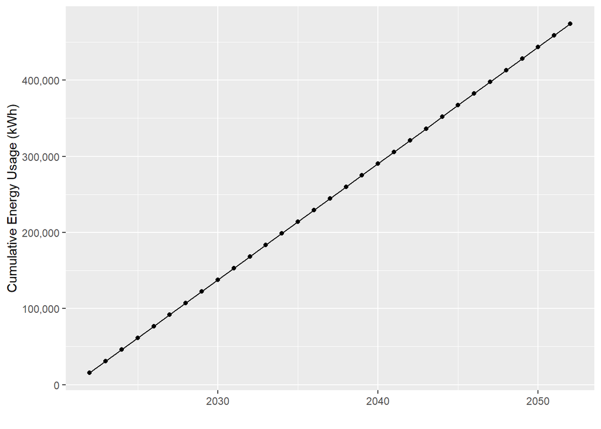

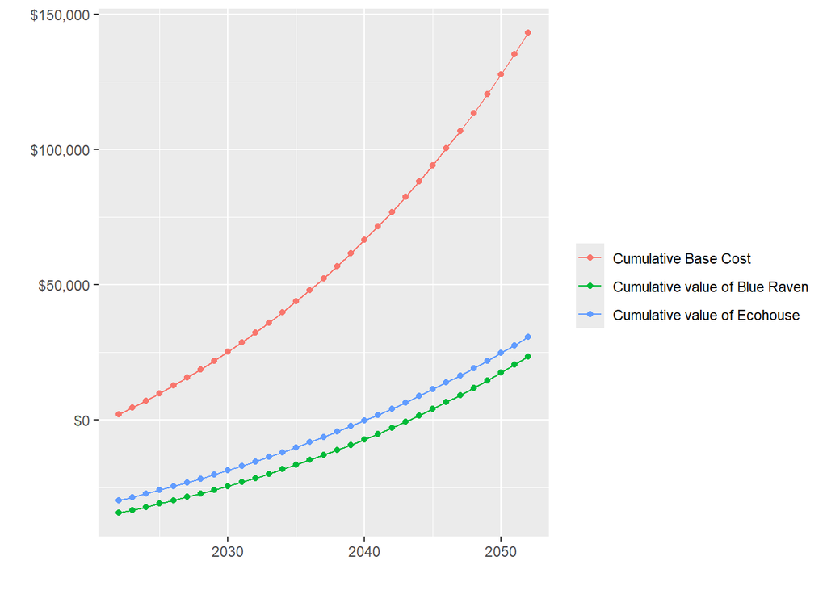

### 1.5 Calculate Forecasted 25 yr Net Present Value

- Blue Raven: -$1,748.94
- EcoHouse: $5,069.95

The Ecohouse solar options was selected

## 2 Pre-Installation Temperature vs Energy Forecast

### 2.1 Monthly Temperature Timeseries

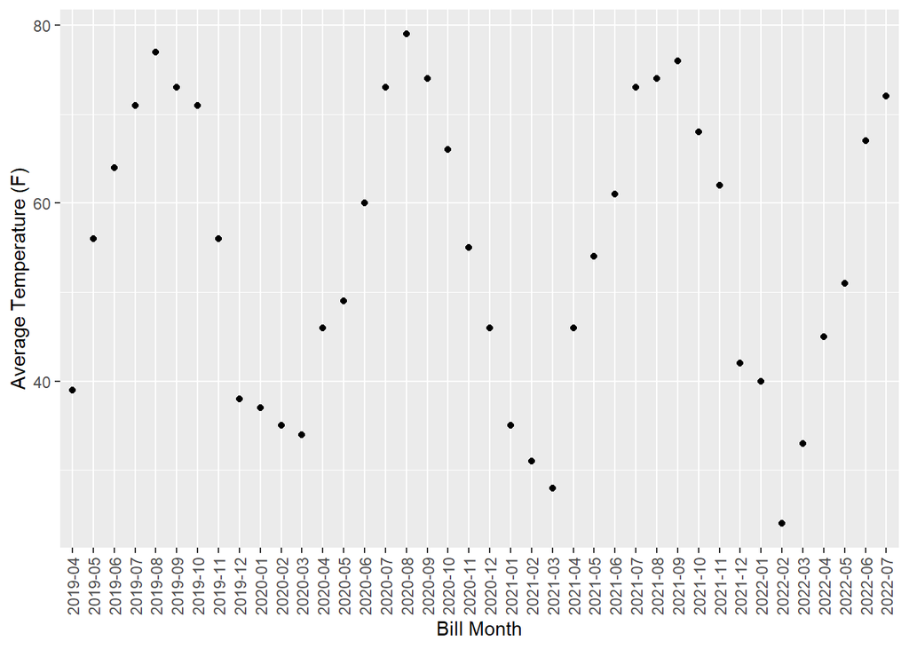

### 2.2 Energy Usage vs Temperature

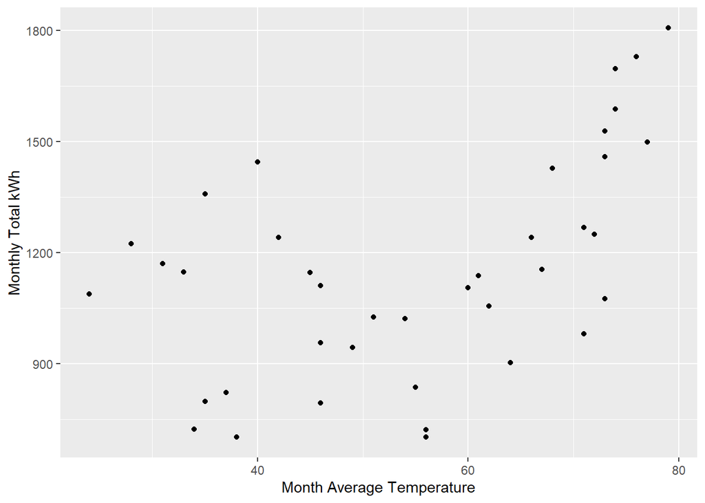

### 2.3 Energy Usage per Day vs Temperature

Energy usage per day should remove some variability due to months of different lengths

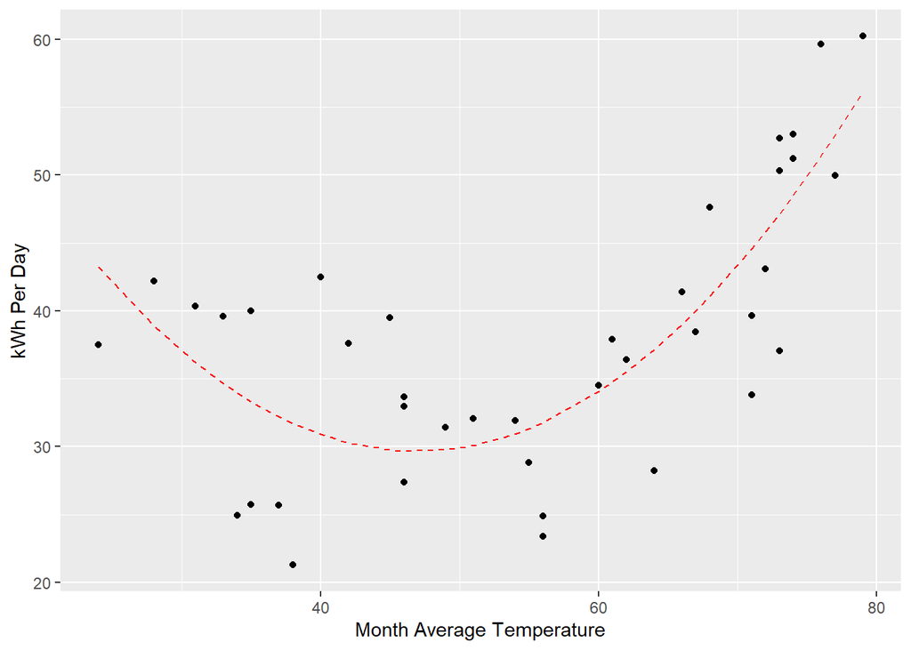

### 2.4 Regression Diagnositics and Fit

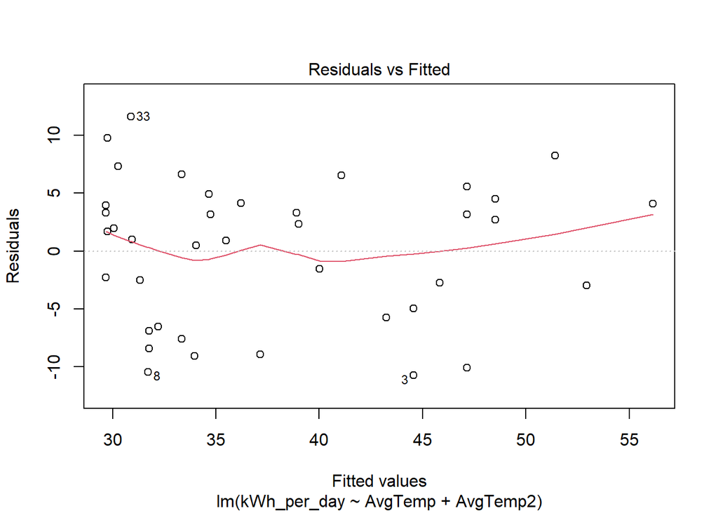

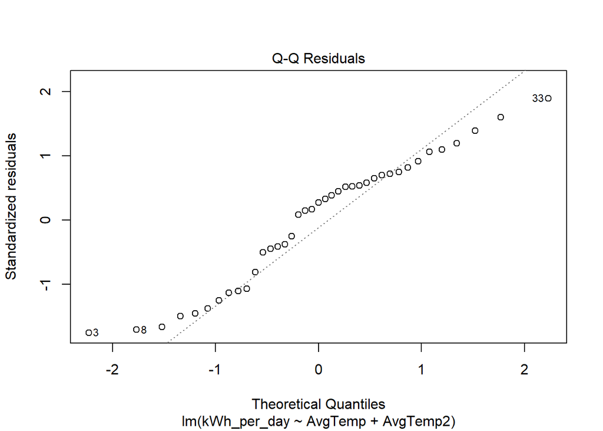

## 3 Actuals and Forecast (Post-Installation)

#### 3.0.1 Actual Temp

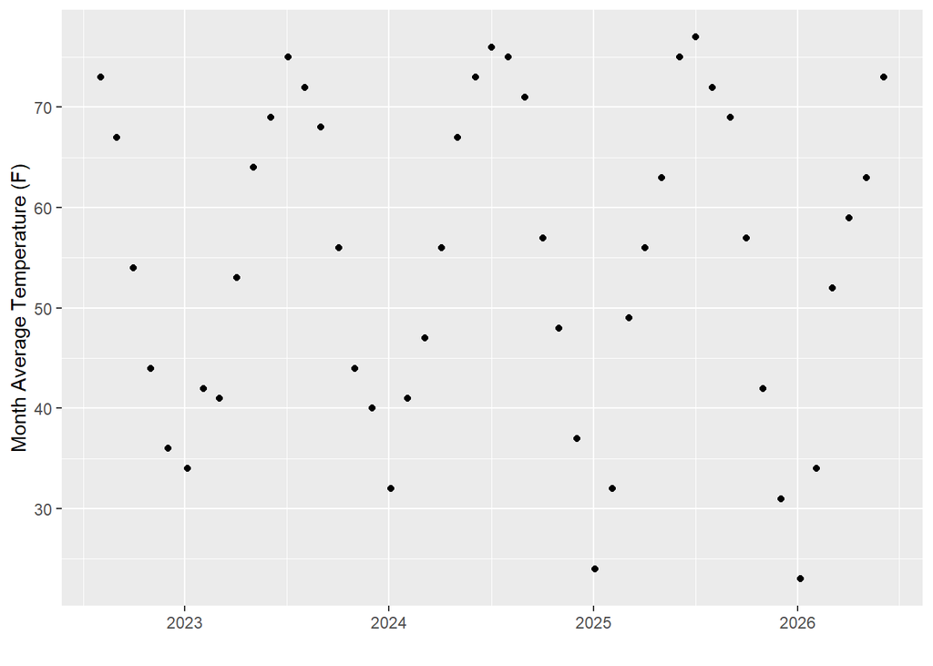

#### 3.0.2 Actual Usage since Installation

- **Total Demand** - The amount of power used in the home
- **From Grid** - The amount of power needed by the house from the grid
- **To Grid** - The amount of power supplied by the solar panels to the grid
- **Solar Production** - The amount of power created by the solar panels

$$Solar\ Production\ +\ From\ Grid =
Actual\ Total\ Demand\ -\ To\ Grid$$

$$To\ Grid < 0$$

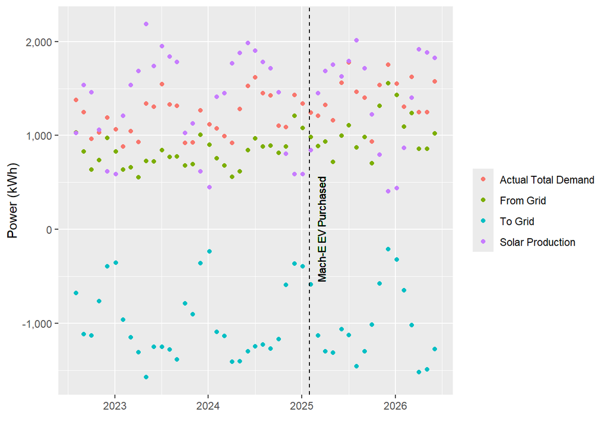

### 3.1 Comparison of Demand and Solar Production

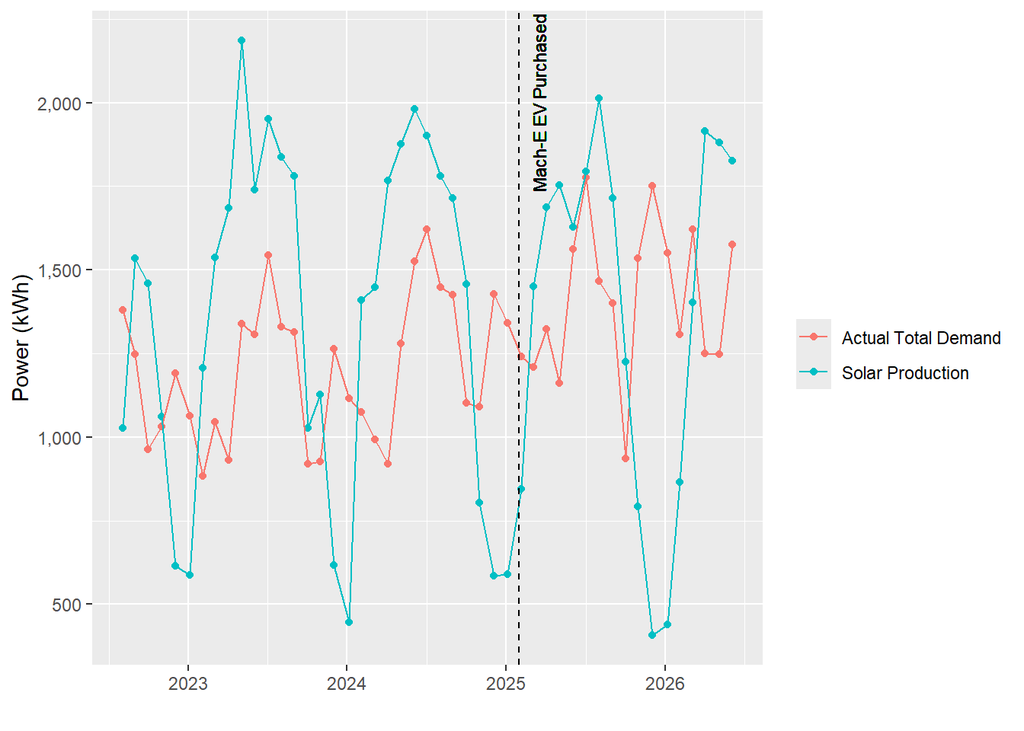

### 3.2 Actual Demand vs Predicted Demand from Avg Temp

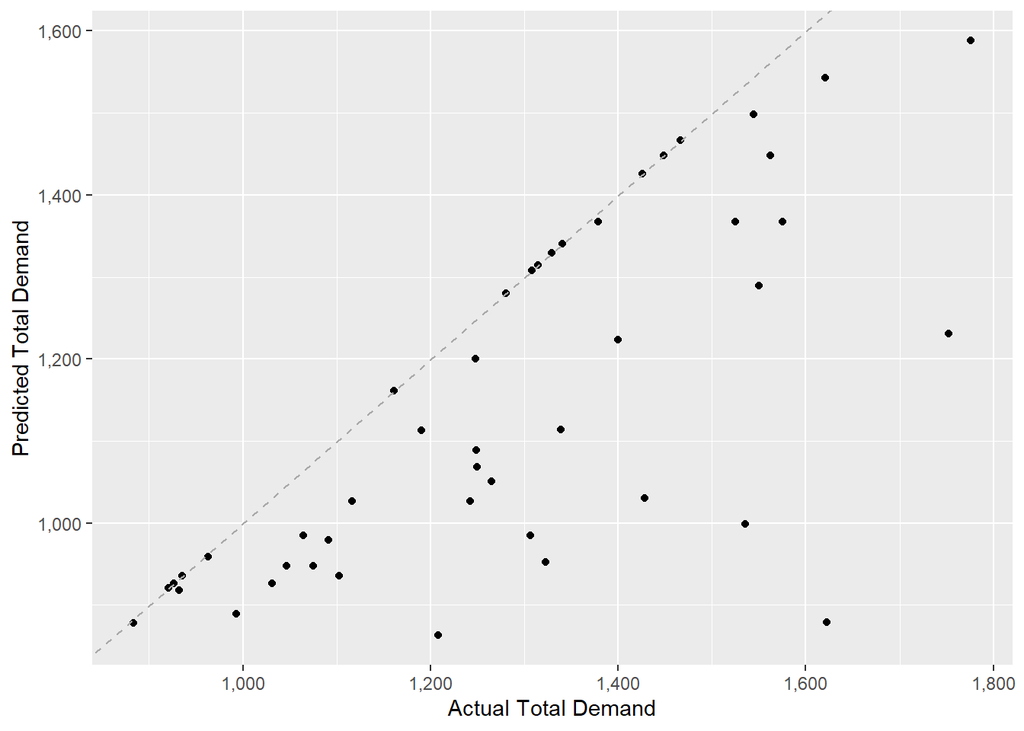

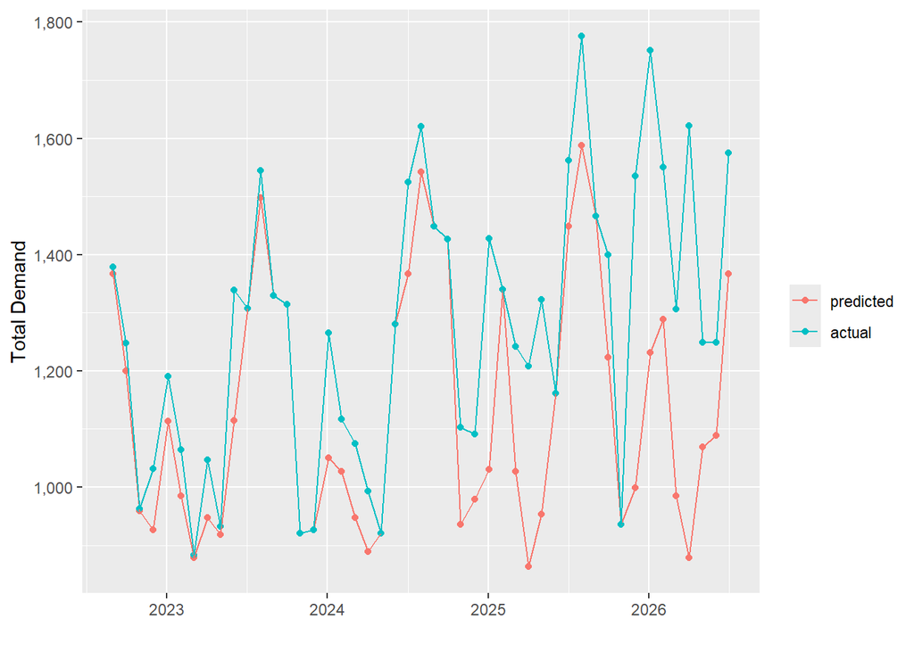

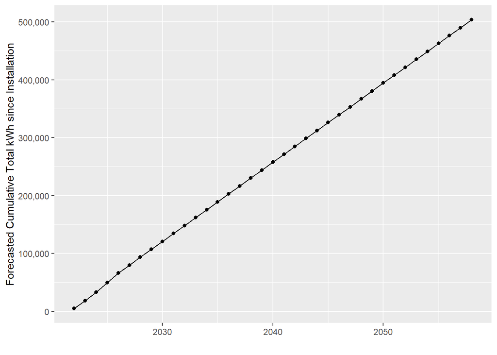

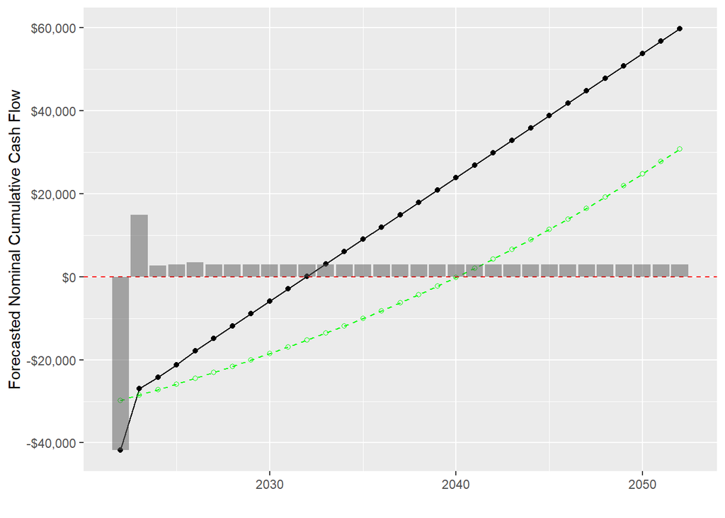

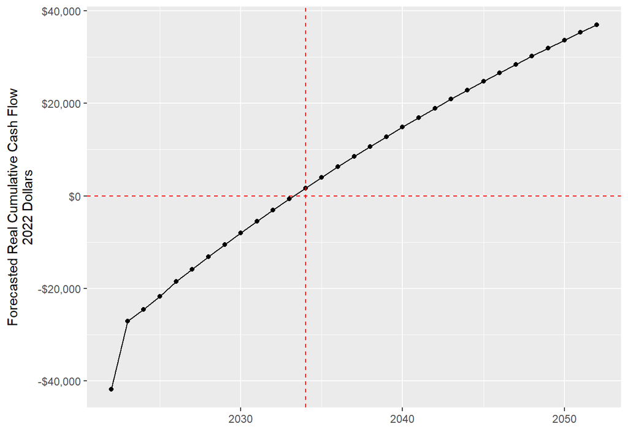

### 3.3 Forecast Return on Investment

- Break Even Year: 2034
- 20 yr NPV in 2042: $18,270.45
- 25 yr NPV in 2047: $27,787.23